# Estimation of the latitude & the longitude (ANOVA)

Lesueur Louis

# Préparation des données

```r
# #Import des donnees
#print('>>>>>>data>>>>>')
ALL_COMMUNES <- read_excel("COMMUNES.xlsx", col_types = c("blank","text", "blank", "text", "numeric", "numeric", "blank", "blank", "numeric", "text", "blank"))
```

```
`col_type = "blank"` deprecated. Use "skip" instead.
```

# Statistiques Univariées

## Représentation des données

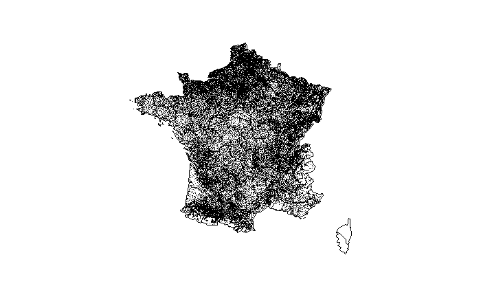

```r
#plot(test_COMMUNES$longitude, test_COMMUNES$latitude)

map('france')
points(C*ALL_COMMUNES$longitude,C*ALL_COMMUNES$latitude,pch='.')
```

Les villes ne sont pas uniformément placées sur la carte; ce qui est assez représentatif de la réalité.

Pas de points en Corse.

## Analyse Univariée de la latitude et de la longitude

```r
summary(as.data.frame(list(latitude=ALL_COMMUNES$latitude,longitude=ALL_COMMUNES$longitude)))
```

```
    latitude        longitude
 Min.   :0.7393   Min.   :-0.08891
 1st Qu.:0.7897   1st Qu.: 0.01130
 Median :0.8279   Median : 0.04528
 Mean   :0.8207   Mean   : 0.04667
 3rd Qu.:0.8525   3rd Qu.: 0.08383
 Max.   :0.8914   Max.   : 0.14279
```

## Analyse Univariée des noms des villes selon la présence de caractères

Regardons d’abord les fréquences d’apparition de chaque caractère dans les noms de ville:

```r
summary(logistic_table)
```

```
     a               z               e               r               t
 Mode :logical   Mode :logical   Mode :logical   Mode :logical   Mode :logical
 FALSE:12114     FALSE:30413     FALSE:8801      FALSE:13844     FALSE:19704
 TRUE :20475     TRUE :2176      TRUE :23788     TRUE :18745     TRUE :12885
     y               u               i               o               p
 Mode :logical   Mode :logical   Mode :logical   Mode :logical   Mode :logical
 FALSE:26769     FALSE:17490     FALSE:14070     FALSE:17129     FALSE:30391
 TRUE :5820      TRUE :15099     TRUE :18519     TRUE :15460     TRUE :2198
     q               s               d               f               g
 Mode :logical   Mode :logical   Mode :logical   Mode :logical   Mode :logical
 FALSE:31817     FALSE:18397     FALSE:27354     FALSE:31544     FALSE:27115
 TRUE :772       TRUE :14192     TRUE :5235      TRUE :1045      TRUE :5474
     h               j               k               l               m
 Mode :logical   Mode :logical   Mode :logical   Mode :logical   Mode :logical
 FALSE:27234     FALSE:32309     FALSE:32505     FALSE:18513     FALSE:27791
 TRUE :5355      TRUE :280       TRUE :84        TRUE :14076     TRUE :4798
     w               x               c               v               b
 Mode :logical   Mode :logical   Mode :logical   Mode :logical   Mode :logical
 FALSE:32449     FALSE:30637     FALSE:26049     FALSE:28038     FALSE:29962
 TRUE :140       TRUE :1952      TRUE :6540      TRUE :4551      TRUE :2627
     n               é               -               è               _
 Mode :logical   Mode :logical   Mode :logical   Mode :logical   Mode :logical
 FALSE:13515     FALSE:28852     FALSE:20140     FALSE:30485     FALSE:30518
 TRUE :19074     TRUE :3737      TRUE :12449     TRUE :2104      TRUE :2071
     ç               à               ê               ô               ë
 Mode :logical   Mode :logical   Mode :logical   Mode :logical   Mode :logical
 FALSE:32498     FALSE:32565     FALSE:32438     FALSE:32422     FALSE:32479
 TRUE :91        TRUE :24        TRUE :151       TRUE :167       TRUE :110
     ÿ               î               â               û               ü
 Mode :logical   Mode :logical   Mode :logical   Mode :logical   Mode :logical
 FALSE:32587     FALSE:32550     FALSE:32178     FALSE:32554     FALSE:32586
 TRUE :2         TRUE :39        TRUE :411       TRUE :35        TRUE :3
     A               Z               E               R               T
 Mode :logical   Mode :logical   Mode :logical   Mode :logical   Mode :logical
 FALSE:29610     FALSE:32562     FALSE:31891     FALSE:30705     FALSE:31031
 TRUE :2979      TRUE :27        TRUE :698       TRUE :1884      TRUE :1558
     Y               U               I               O               P
 Mode :logical   Mode :logical   Mode :logical   Mode :logical   Mode :logical
 FALSE:32477     FALSE:32434     FALSE:32295     FALSE:31757     FALSE:29772
 TRUE :112       TRUE :155       TRUE :294       TRUE :832       TRUE :2817
     Q               S               D               F               G
 Mode :logical   Mode :logical   Mode :logical   Mode :logical   Mode :logical
 FALSE:32386     FALSE:26197     FALSE:31397     FALSE:30864     FALSE:30533
 TRUE :203       TRUE :6392      TRUE :1192      TRUE :1725      TRUE :2056
     H               J               K               L               M
 Mode :logical   Mode :logical   Mode :logical   Mode :logical   Mode :logical
 FALSE:31514     FALSE:31819     FALSE:32517     FALSE:27626     FALSE:27744
 TRUE :1075      TRUE :770       TRUE :72        TRUE :4963      TRUE :4845
     W               X               C               V               B
 Mode :logical   Mode :logical   Mode :logical   Mode :logical   Mode :logical
 FALSE:32370     FALSE:32564     FALSE:27269     FALSE:29672     FALSE:28035
 TRUE :219       TRUE :25        TRUE :5320      TRUE :2917      TRUE :4554
     N
 Mode :logical
 FALSE:31614
 TRUE :975
```

Les lettres rares sont: j,k,w,ç,à,ê,ô,ë,ÿ,î,â,û,ü,Z,Y,U,I,Q,K,W,X

## Placement des villes selon la présence de caractères

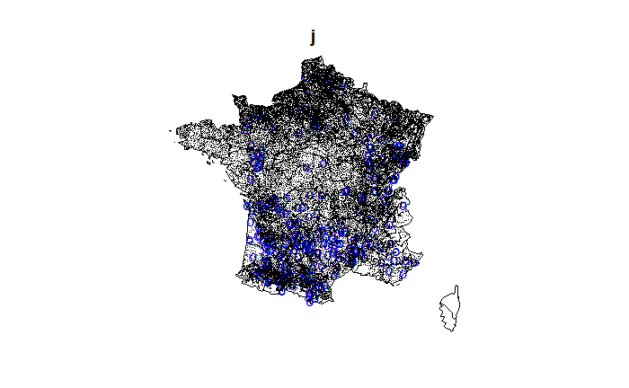

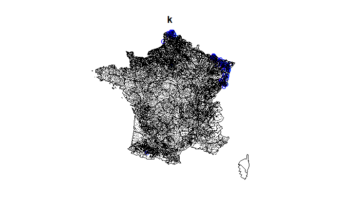

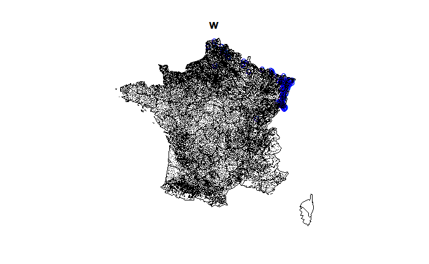

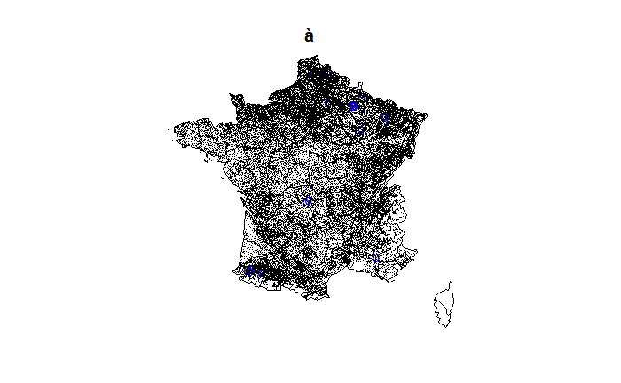

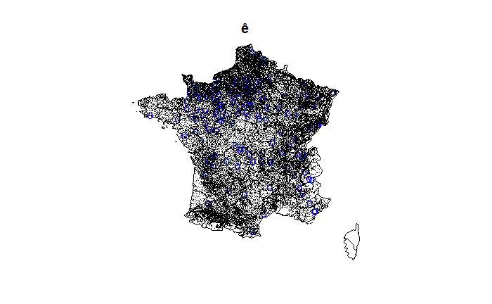

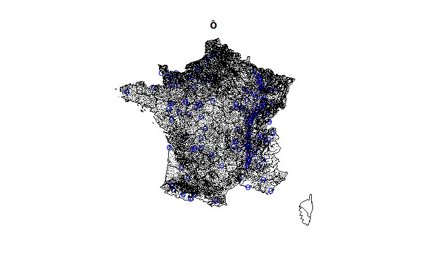

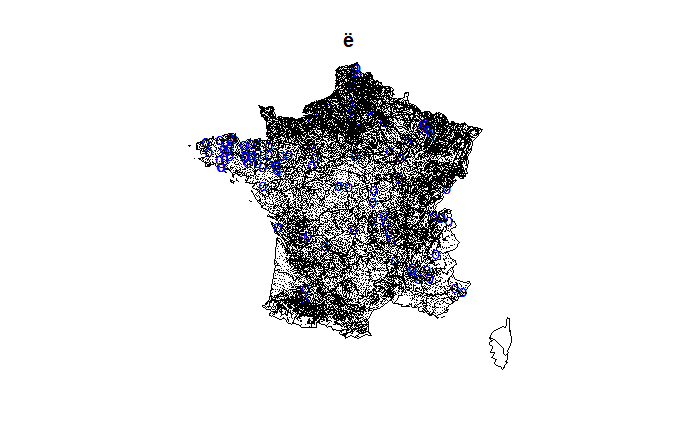

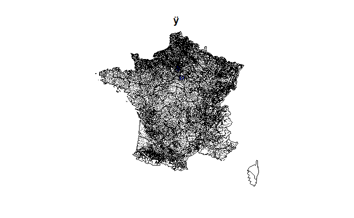

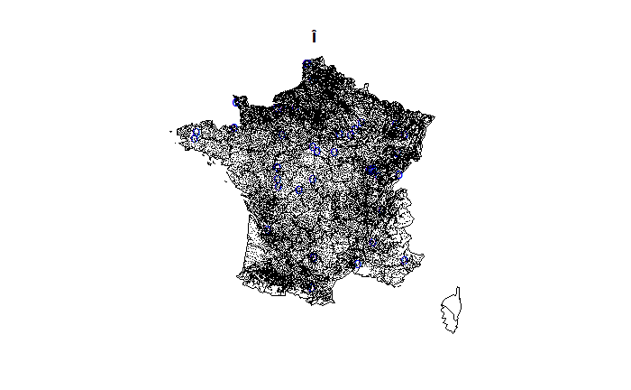

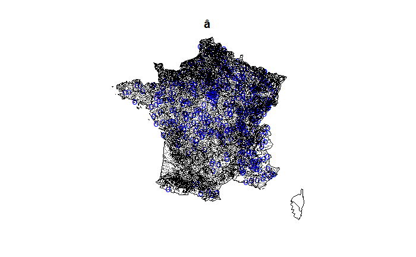

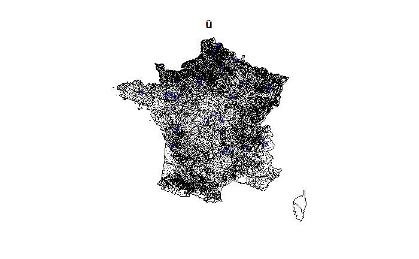

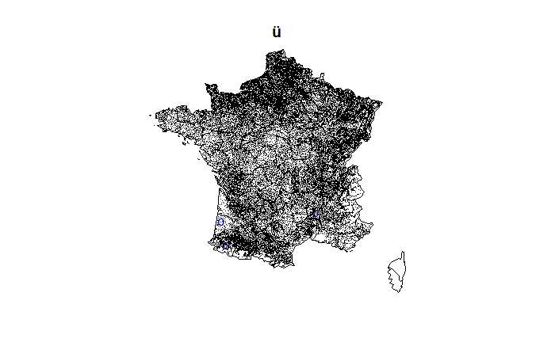

[8 more figures not shown]

```r
p2=c('a','z','e','r','t','y','u','i','o','p','q','s','d','f','g','h','l','m','w','x','c','v','b','n','é','-','è','_','A','E','R','T','O','P','S','D','F','G','H','J','L','M','C','V','B','N') #common letters
p3=c('j','k','w','à','ê','ô','ë','ÿ','î','â','û','ü','Z','Y','U','I','Q','K','W','X') #rare letters

#print('First the rare letters')
#par(mfrow=c(2,2))
for(i in p3){
  tmp=(1:length(logistic_table[,1]))*logistic_table[,i]
  map('france')
  points(C*COMMUNES$longitude[tmp],C*COMMUNES$latitude[tmp],main=i,col='blue',pch='o')
  points(C*COMMUNES$longitude[-tmp],C*COMMUNES$latitude[-tmp],pch='.')
  title(main=i)
}
```

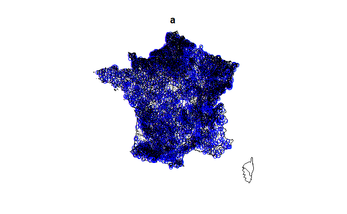

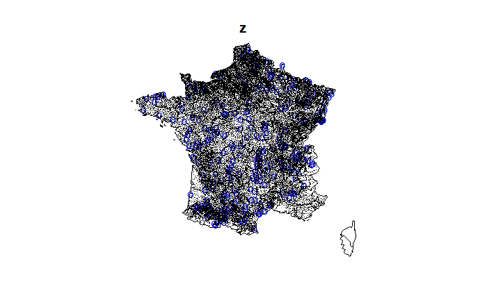

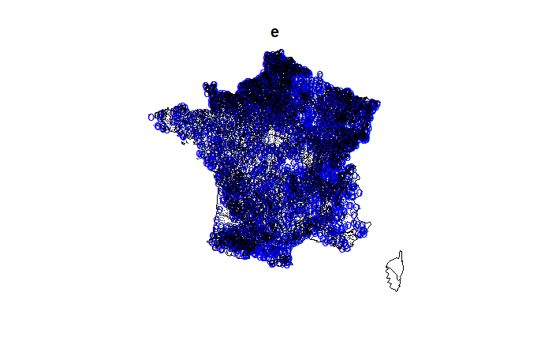

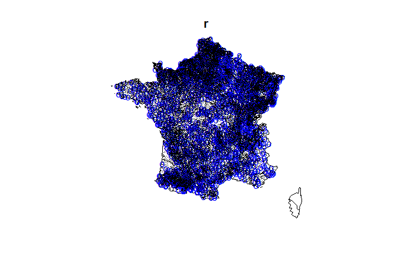

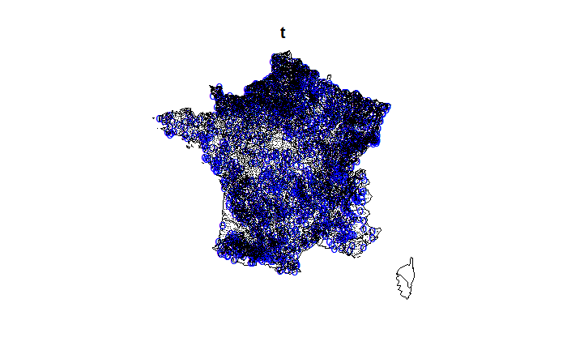

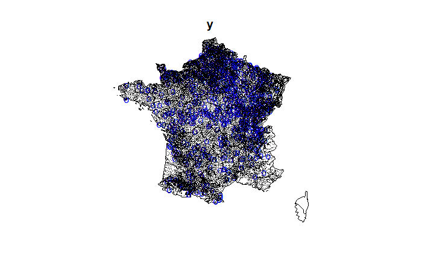

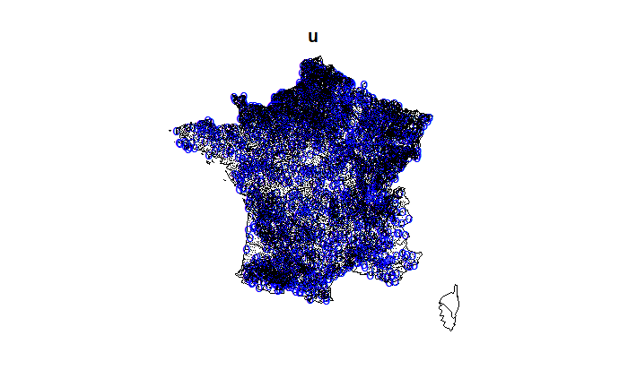

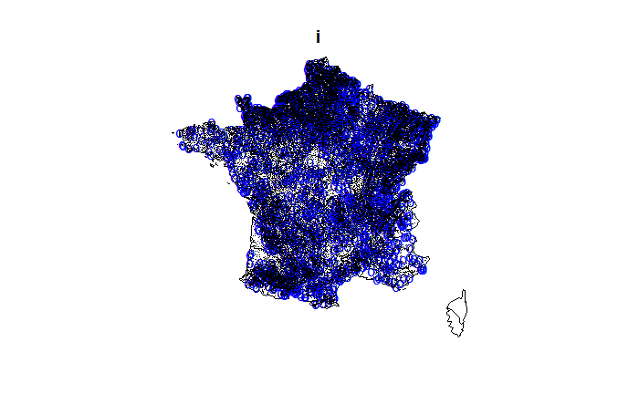

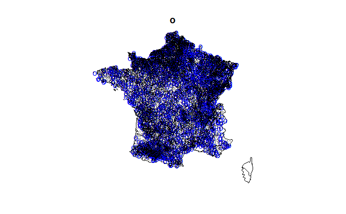

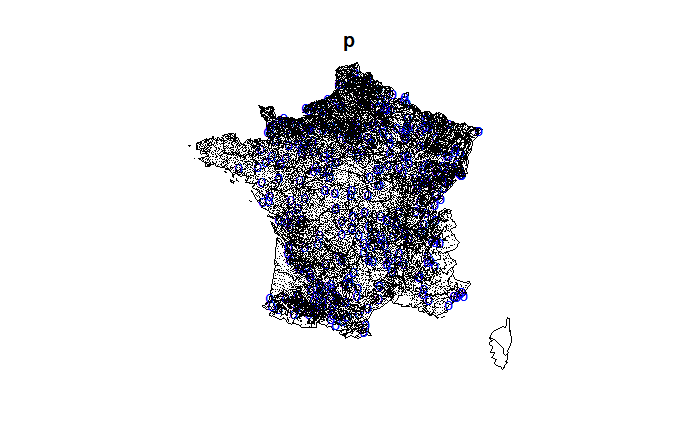

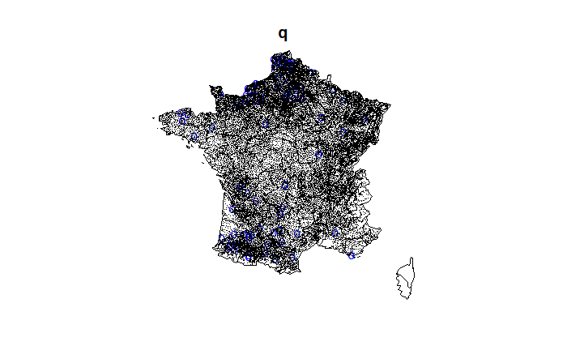

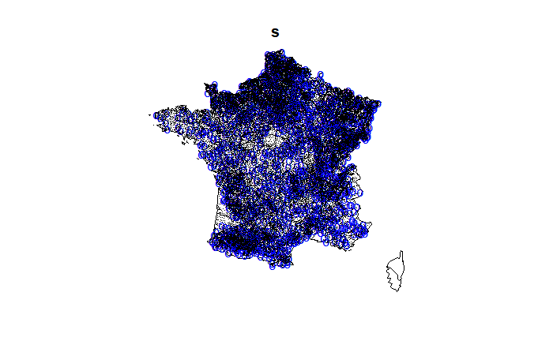

[34 more figures not shown]

```r
#print('<<<<<<<<<<')
#print('Then the others')
for(i in p2){
  tmp=(1:length(logistic_table_test[,1]))*logistic_table_test[,i]
  map('france')
  points(C*test_COMMUNES$longitude[tmp],C*test_COMMUNES$latitude[tmp],main=i,pch='o',col='blue')
  points(C*COMMUNES$longitude[-tmp],C*COMMUNES$latitude[-tmp],pch='.')
  title(main=i)
}
```

```r
rm(list=c('i','tmp','p2','p3'))
#print('<<<<<<<<<<<')
```

# Statistiques Bivariées

## Création du modéle régulier

```r
#print('>>>>>>>>>values>>>>>>>')
# #Ajout de modalites
logistic_table<-logistic_table.initialization(p,COMMUNES)
logistic_table_test<-logistic_table.initialization(p,test_COMMUNES)
# #Attention au - t au _
p2=c('a','z','e','r','t','y','u','i','o','p','q','s','d','f','g','h','j','k','l','m','w','x','c','v','b','n','é','tiret','è','underscore','ç','à','ê','ô','ë','ÿ','î','â','û','ü','A','Z','E','R','T','Y','U','I','O','P','Q','S','D','F','G','H','J','K','L','M','W','X','C','V','B','N')

#Initialisation des data frames pour les lm et des noms des variables
latitude.lm.data<-data.lm(logistic_table,COMMUNES$latitude,p)
longitude.lm.data<-data.lm(logistic_table,COMMUNES$longitude,p)
colnames(logistic_table)<-p2
colnames(logistic_table_test)<-p2
colnames(latitude.lm.data)<-c('latitude',p2)
colnames(longitude.lm.data)<-c('longitude',p2)

#Formule des lm
formule_lat_reg<-formula(paste("latitude ~ ", paste(p2, collapse= "+")))
formule_long_reg<-formula(paste("longitude~",paste(p2,collapse="+")))
#print('<<<<<<<<<<<<<<<')

#print('>>>>>>>>creating model for the latitude>>>>>>>>')
latitude.lm_reg=lm(formule_lat_reg,data=latitude.lm.data)
#print('<<<<<<<<<<<<<<<')
#print('>>>>>>>>creating the model for longitude>>>>>>>')
longitude.lm_reg=lm(formule_long_reg,data=longitude.lm.data)
#print('<<<<<<<<<<<<<<<<<<<')
```

Remarquons qu’on a ajouté maintenant le nombre d’apparitions des lettres par nom de ville.

ex: strasbourg->[‘a’=1,‘s’=3,‘r’=2,‘t’=1,‘b’=1,‘o’=1,‘u’=1,‘g’=1,0…0]

## Analyse bivariée et Modèle Singulier

### Fischer tests pour la Latitude

Pour faire une première sélection des variables avant l’ajout d’interactions; essayons de repérer les variables significatives sur la latitude.

```r
latanova<-anova(latitude.lm_reg)
latanova
```

```
Analysis of Variance Table

Response: latitude
              Df Sum Sq Mean Sq   F value    Pr(>F)
a              1  1.392 1.39236 1158.2286 < 2.2e-16 ***
z              1  0.219 0.21931  182.4324 < 2.2e-16 ***
e              1  0.365 0.36472  303.3930 < 2.2e-16 ***
r              1  0.045 0.04496   37.3975 9.744e-10 ***
t              1  0.003 0.00313    2.5997 0.1068932
y              1  0.784 0.78448  652.5615 < 2.2e-16 ***
u              1  0.064 0.06418   53.3838 2.806e-13 ***
i              1  0.377 0.37749  314.0142 < 2.2e-16 ***
o              1  0.034 0.03373   28.0574 1.185e-07 ***
p              1  0.038 0.03807   31.6704 1.842e-08 ***
q              1  0.003 0.00297    2.4742 0.1157397
s              1  0.149 0.14913  124.0489 < 2.2e-16 ***
d              1  0.428 0.42779  355.8555 < 2.2e-16 ***
f              1  0.040 0.03968   33.0072 9.264e-09 ***
g              1  0.018 0.01834   15.2582 9.396e-05 ***
h              1  0.205 0.20475  170.3227 < 2.2e-16 ***
j              1  0.147 0.14745  122.6551 < 2.2e-16 ***
k              1  0.093 0.09262   77.0433 < 2.2e-16 ***
l              1  0.412 0.41227  342.9480 < 2.2e-16 ***
m              1  0.281 0.28142  234.1014 < 2.2e-16 ***
w              1  0.031 0.03097   25.7586 3.890e-07 ***
x              1  0.000 0.00011    0.0899 0.7643433
c              1  0.001 0.00085    0.7054 0.4009911
b              1  0.010 0.01002    8.3362 0.0038889 **
n              1  0.219 0.21905  182.2113 < 2.2e-16 ***
é              1  0.020 0.02047   17.0304 3.688e-05 ***
tiret          1  0.000 0.00005    0.0391 0.8431788
è              1  0.213 0.21270  176.9319 < 2.2e-16 ***
underscore     1  0.094 0.09407   78.2501 < 2.2e-16 ***
ç              1  0.003 0.00338    2.8146 0.0934205 .
à              1  0.000 0.00001    0.0053 0.9417544
ê              1  0.002 0.00235    1.9527 0.1623105
ô              1  0.004 0.00425    3.5393 0.0599391 .
ë              1  0.016 0.01611   13.3975 0.0002524 ***
ÿ              1  0.003 0.00299    2.4849 0.1149537
î              1  0.005 0.00459    3.8159 0.0507781 .
```

[output cut: 17 more lines]

```
G              1  0.000 0.00009    0.0742 0.7853295
H              1  0.341 0.34110  283.7423 < 2.2e-16 ***
J              1  0.012 0.01222   10.1688 0.0014297 **
K              1  0.037 0.03656   30.4092 3.525e-08 ***
L              1  0.052 0.05241   43.5937 4.103e-11 ***
M              1  0.003 0.00272    2.2601 0.1327529
W              1  0.254 0.25436  211.5882 < 2.2e-16 ***
X              1  0.003 0.00272    2.2596 0.1327985
C              1  0.158 0.15809  131.5028 < 2.2e-16 ***
V              1  0.066 0.06625   55.1066 1.170e-13 ***
B              1  0.017 0.01731   14.3988 0.0001482 ***
N              1  0.000 0.00004    0.0305 0.8613591
Residuals  32522 39.096 0.00120
---
Signif. codes:  0 ‘***’ 0.001 ‘**’ 0.01 ‘*’ 0.05 ‘.’ 0.1 ‘ ’ 1
```

### Fischer tests pour la longitude

```r
longanova<-anova(longitude.lm_reg)
longanova
```

```
Analysis of Variance Table

Response: longitude
              Df Sum Sq Mean Sq  F value    Pr(>F)
a              1  0.486 0.48590 262.6043 < 2.2e-16 ***
z              1  0.000 0.00016   0.0883 0.7664047
e              1  0.070 0.07011  37.8911 7.568e-10 ***
r              1  0.001 0.00055   0.2973 0.5855992
t              1  0.026 0.02627  14.2004 0.0001646 ***
y              1  0.431 0.43103 232.9516 < 2.2e-16 ***
u              1  0.185 0.18532 100.1593 < 2.2e-16 ***
i              1  0.035 0.03535  19.1033 1.242e-05 ***
o              1  0.010 0.00972   5.2510 0.0219411 *
p              1  0.001 0.00143   0.7707 0.3800131
q              1  0.151 0.15108  81.6495 < 2.2e-16 ***
s              1  0.064 0.06377  34.4667 4.378e-09 ***
d              1  0.176 0.17557  94.8858 < 2.2e-16 ***
f              1  0.142 0.14150  76.4755 < 2.2e-16 ***
g              1  0.000 0.00022   0.1195 0.7296189
h              1  0.604 0.60416 326.5215 < 2.2e-16 ***
j              1  0.002 0.00209   1.1289 0.2880184
k              1  0.171 0.17119  92.5188 < 2.2e-16 ***
l              1  0.017 0.01655   8.9450 0.0027844 **
m              1  0.178 0.17783  96.1070 < 2.2e-16 ***
w              1  0.583 0.58300 315.0852 < 2.2e-16 ***
x              1  0.210 0.21009 113.5466 < 2.2e-16 ***
c              1  0.007 0.00737   3.9840 0.0459424 *
b              1  0.054 0.05363  28.9855 7.343e-08 ***
n              1  0.121 0.12069  65.2280 6.900e-16 ***
é              1  0.861 0.86081 465.2307 < 2.2e-16 ***
tiret          1  0.113 0.11330  61.2335 5.222e-15 ***
è              1  0.026 0.02645  14.2966 0.0001564 ***
underscore     1  0.074 0.07402  40.0067 2.564e-10 ***
ç              1  0.001 0.00115   0.6192 0.4313595
à              1  0.001 0.00058   0.3160 0.5740441
ê              1  0.003 0.00266   1.4362 0.2307630
ô              1  0.045 0.04452  24.0626 9.370e-07 ***
ë              1  0.038 0.03758  20.3096 6.610e-06 ***
ÿ              1  0.000 0.00000   0.0001 0.9907489
î              1  0.000 0.00010   0.0555 0.8137223
```

[output cut: 17 more lines]

```
G              1  0.058 0.05759  31.1260 2.437e-08 ***
H              1  0.028 0.02762  14.9299 0.0001118 ***
J              1  0.026 0.02647  14.3046 0.0001558 ***
K              1  0.016 0.01623   8.7700 0.0030645 **
L              1  0.107 0.10690  57.7736 3.020e-14 ***
M              1  0.029 0.02906  15.7036 7.424e-05 ***
W              1  0.169 0.16853  91.0842 < 2.2e-16 ***
X              1  0.028 0.02792  15.0877 0.0001028 ***
C              1  0.345 0.34521 186.5719 < 2.2e-16 ***
V              1  0.107 0.10698  57.8201 2.949e-14 ***
B              1  0.098 0.09760  52.7503 3.873e-13 ***
N              1  0.040 0.04032  21.7904 3.053e-06 ***
Residuals  32522 60.175 0.00185
---
Signif. codes:  0 ‘***’ 0.001 ‘**’ 0.01 ‘*’ 0.05 ‘.’ 0.1 ‘ ’ 1
```

Les lettres significatives:

- 0: a e t y u i q s d f h k m w x b n é – è _ ô ë A Z E R T Y P Q S D G H J L M W X C V B N
- <1% : l I K
- <5%: o c F

### Conclusion

On remarque finalement que la plupart des lettres semble effectivement (beaucoup de p-values à 0) avoir un effet très significatif sur la latitude et la longitude.

Les lettres rares ne sont les seules à être vraiment importantes: les lettres très fréquentes (comme le a) aussi: c’est peut-être leur absence ou le fait qu’il y ait plusieurs occurences de ces lettres.

## Vérifications graphiques des hypothéses du modèle

### Latitude

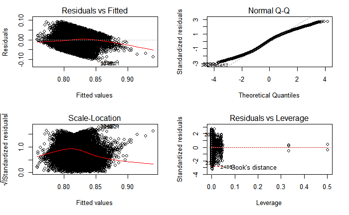

```r
par(mfrow=c(2,2))
plot(latitude.lm_reg)
```

**Residuals vs fitted:** Nous ne sommes pas sensés observer une tendance particulière mais ici nous voyons bien une tendance (décroissante); l’éspérance des résidus n’est pas nulle.

**QQ-plot:** La latitude ne semble pas suivre une loi normale (on aurait pu s’y attendre…)

**Scale Location:** Quelques points un peu extrêmes mais nous ne voyons pas de tendance particulière.

**Residuals vs leverage** Quelques points sont très loins sur la droite. Si aucun point ne semble abérant il y a l’air d’y avoir un effet de classes.

Voyons quelques points suspects:

```r
COMMUNES[23295,]
```

| nom | code_postal | longitude | latitude | departement | region |
| --- | --- | --- | --- | --- | --- |
| Alçay-Alçabéhéty-Sunharette | 64470 | -0.01589703 | 0.7521788 | 64 | AQ |

```r
COMMUNES[20802,]
```

| nom | code_postal | longitude | latitude | departement | region |
| --- | --- | --- | --- | --- | --- |
| Pont-à-Marcq | 59710 | 0.05437186 | 0.8817501 | 59 | NP |

```r
COMMUNES[22265,]
```

| nom | code_postal | longitude | latitude | departement | region |
| --- | --- | --- | --- | --- | --- |
| Cauchy-à-la-Tour | 62260 | 0.04272664 | 0.8815028 | 62 | NP |

Effectivement ces noms de villes ont de nombreux caractères rares et sont extrèmes en ce sens…

### Longitude:

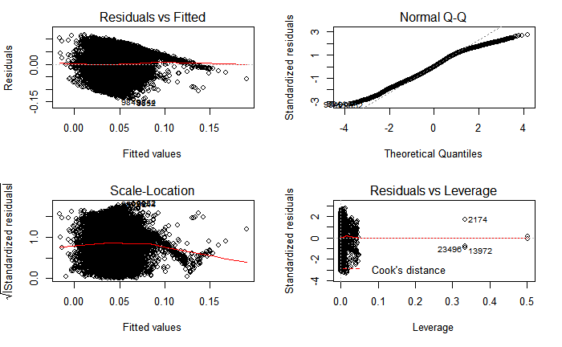

```r
par(mfrow=c(2,2))
plot(longitude.lm_reg)
```

Regardons quelques points ayant eu un fort leverage:

```r
print(COMMUNES[2174,])
```

| nom | code_postal | longitude | latitude | departement | region |
| --- | --- | --- | --- | --- | --- |
| Vogüé | 7200 | 0.07706599 | 0.777583 | 7 | RA |

```r
print(COMMUNES[23496,])
```

| nom | code_postal | longitude | latitude | departement | region |
| --- | --- | --- | --- | --- | --- |
| Geüs-d'Oloron | 64400 | -0.01230942 | 0.7548889 | 64 | AQ |

```r
print(COMMUNES[13972,])
```

| nom | code_postal | longitude | latitude | departement | region |
| --- | --- | --- | --- | --- | --- |
| Lüe | 40210 | -0.01716725 | 0.771964 | 40 | AQ |

```r
NA
```

Effectivement les noms qui resortent ne sont pas les plus banals…

## Tentative d’amélioration du modéle régulier

### Estimation de la log-longitude et de la log-latitude

```r
#print('>>>>>>>Values>>>>>>>')
# #Log-longitude
sign.longitude<-sign(longitude.lm.data[,1])
loglongitude.lm.data<-longitude.lm.data
loglongitude.lm.data[,1]<-log(abs(longitude.lm.data[,1]))
colnames(loglongitude.lm.data)<-c('loglongitude',p2)
formule_loglong_reg<-formula(paste('loglongitude~',paste(p2,collapse='+')))
# #Log-latitude
sign.latitude<-sign(latitude.lm.data[,1])
loglatitude.lm.data<-latitude.lm.data
loglatitude.lm.data[,1]<-log(abs(latitude.lm.data[,1]))
colnames(loglatitude.lm.data)<-c('loglatitude',p2)
formule_loglat_reg<-formula(paste('loglatitude~',paste(p2,collapse='+')))
#print('<<<<<<<<values<<<<<<<<')
#print('>>>>>>>models>>>>>>>>>')
loglongitude.lm=lm(formule_loglong_reg,data=loglongitude.lm.data)
loglatitude.lm=lm(formule_loglat_reg,data=loglatitude.lm.data)
#print('<<<<<<<<models<<<<<<<<')
```

Nous allons regarder les graphes de diagnostiques de ces nouveaux modèles linéaires pour voir si l’étude des log-longitudes et log-latitudes par des lois gaussiennes a plus de sens.

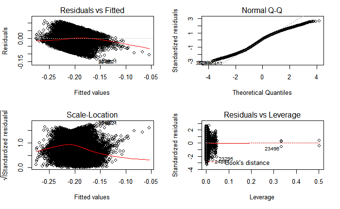

```r
#print('loglatitude:')
par(mfrow=c(2,2))
plot(loglatitude.lm)
#print('loglongitude')
par(mfrow=c(2,2))
```

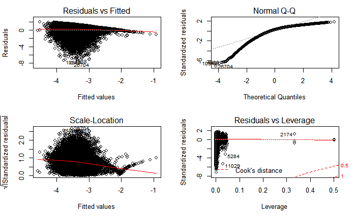

```r
plot(loglongitude.lm)
```

### Estimation de la sqrt-longitude et de la sqrt-latitude

On va utiliser la bijection suivante:

$f:x->sign(x)\sqrt{|x|}$

```r
#print('>>>>>>>>>>>>values>>>>>>>>>>>')
# #sqrt-longitude
sqrtlongitude.lm.data<-longitude.lm.data
sqrtlongitude.lm.data[,1]<-sqrt(abs(longitude.lm.data[,1]))
colnames(sqrtlongitude.lm.data)<-c('sqrtlongitude',p2)
formule_sqrtlong_reg<-paste('sqrtlongitude~',paste(p2,collapse='+'))
# #sqrt-latitude
sqrtlatitude.lm.data<-latitude.lm.data
sqrtlatitude.lm.data[,1]<-sqrt(abs(latitude.lm.data[,1]))
colnames(sqrtlatitude.lm.data)<-c('sqrtlatitude',p2)
formule_sqrtlat_reg<-paste('sqrtlatitude~',paste(p2,collapse='+'))
# #We have already caught the sign of the latitude and the longitude
#print('<<<<<<<<<<<<<values<<<<<<<<<<')
#print('>>>>>>>>>>>>>>models<<<<<<<<<<<<')
sqrtlongitude.lm=lm(formule_sqrtlong_reg,data=sqrtlongitude.lm.data)
sqrtlatitude.lm=lm(formule_sqrtlat_reg,data=sqrtlatitude.lm.data)
#print('<<<<<<<<models<<<<<<<')
```

Regardons de même les graphes de diagnostique:*

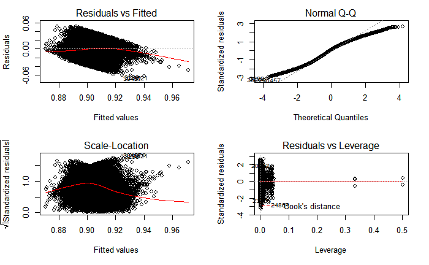

```r
par(mfrow=c(2,2))
#print('sqrt latitude')
plot(sqrtlatitude.lm)
```

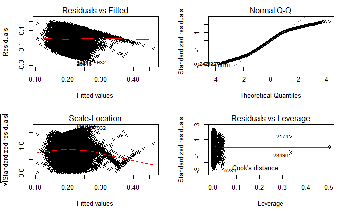

```r
#print('sqrt longitude')
plot(sqrtlongitude.lm)
```

### Conclusion:

Les fonctions les plus communes appliquées à la latitude et la longitude ne donnent pas des données ayant l’air de suivre les hypothèses du modéle linéaire gaussien.

Cela a même l’air d’être pire: les tendances/leverage/qq-plot ressemblent encore moins à des droites

## Sélection des variables

Procédure anova1: on fait les tests bivariés d’influence sur les variables d’intérêt et on garde les covariables dont les tests ont une p-values sont <5%.

Attention néanmoins aux tests multiples (avec 5% d’erreur par test à 20 tests on fait 100% d’erreur finalement).

```r
#Procedure anova1 classique
#Variables significatives
lat_selec_anova<-rownames(latanova[which(latanova[,5]<5/100),])
long_selec_anova<-rownames(longanova[which(longanova[,5]<5/100),])

#Creation des modeles
latitude.lm_reg_anova<-lm(formula(paste('latitude~',paste(lat_selec_anova,collapse='+'))),data=latitude.lm.data)
longitude.lm_reg_anova<-lm(formula(paste('longitude~',paste(lat_selec_anova,collapse='+'))),data=longitude.lm.data)
```

### AIC et BIC

Pour les autres sélections des variables (BIC/AIC/R2) on ne pourra pas faire de procédure exhaustive; le nombre de covariables êtant >20 les temps de calcul deviennent inenvisageables.

On tentera donc une procédure de type backward.

```r
#Procedures backward

#AIC
latitude.lm_reg_aic<-stepAIC(latitude.lm_reg,formule_lat_reg,data=latitude.lm.data,direction="backward",trace=FALSE)
longitude.lm_reg_aic<-stepAIC(longitude.lm_reg,formule_long_reg,data=longitude.lm.data,direction="backward",trace=FALSE)

#BIC
latitude.lm_reg_bic<-stepAIC(latitude.lm_reg,formule_lat_reg,data=latitude.lm.data,direction="backward",trace=FALSE,k=log(length(latitude.lm.data[,1])))
longitude.lm_reg_bic<-stepAIC(longitude.lm_reg,formule_long_reg,data=longitude.lm.data,direction="backward",trace=FALSE,k=log(length(longitude.lm.data[,1])))
```

### Calcul des erreurs sur la base de Test

Pour comparer les performances de ces différents modèles nous allons les tester en prédisant avec la base de tests les latitudes/longitudes des villes de la base de tests, calculer les erreurs quadratiques des prévisions et sélectionner celui minimisant l’erreur quadratique; ce sera le modèle de régression (sans interactions) faisant le meilleur score d’apprentissage.

```r
#Creation des databases

#logistic_table_test<-logistic_table.initialization(p,test_COMMUNES)
test.latitude<-data.lm(logistic_table_test,test_COMMUNES$latitude,p)
test.longitude<-data.lm(logistic_table_test,test_COMMUNES$longitude,p)
colnames(test.latitude)<-c('latitude',p2)
colnames(test.longitude)<-c('longitude',p2)

#Calcul des erreurs

#MODELE COMPLET
err_complete<-c(mean((predict(latitude.lm_reg,newdata=test.latitude)-test.latitude[,1])**2),mean((predict(longitude.lm_reg,newdata=test.longitude)-test.longitude[,1])**2))
#ANOVA
err_anova<-c(mean((predict(latitude.lm_reg_anova,newdata=test.latitude)-test.latitude[,1])**2),mean((predict(longitude.lm_reg_anova,newdata=test.longitude)-test.longitude[,1])**2))
#AIC
err_aic<-c(mean((predict(latitude.lm_reg_aic,newdata=test.latitude)-test.latitude[,1])**2),mean((predict(longitude.lm_reg_aic,newdata=test.longitude)-test.longitude[,1])**2))
#BIC
err_bic<-c(mean((predict(latitude.lm_reg_bic,newdata=test.latitude)-test.latitude[,1])**2),mean((predict(longitude.lm_reg_bic,newdata=test.longitude)-test.longitude[,1])**2))
```

```r
#Resultats
M<-matrix(nrow=5,ncol=2)
M[1,]<-err_complete
M[2,]<-err_anova
M[3,]<-err_aic
M[4,]<-err_bic
M[5,]<-c(var(test_COMMUNES$latitude),var(test_COMMUNES$longitude))
rownames(M)<-c('Modele complet','Modele avec anova type 1', 'Modele AIC backward','Modele BIC backward','Modele trivial')
colnames(M)<-c('Erreur sur la latitude','Erreur sur la longitude')
M
```

```
                         Erreur sur la latitude Erreur sur la longitude
Modele complet                      0.001201088             0.001859551
Modele avec anova type 1            0.001212520             0.001898814
Modele AIC backward                 0.001201929             0.001860830
Modele BIC backward                 0.001209170             0.001867437
Modele trivial                      0.001441735             0.002063376
```

Le modele complet semble être le meilleur en prédiction (et il est certainement le meilleur aussi sur la base d’APP). Ceci dit la différence n’est pas flagrante et quand on regarde le nombre de régresseurs Latitude:66/56/46/44 Longitude:66/56/45/41 Le gain de 25 variables par changement de modèle sans impact sur l’erreur d’apprentissage est à prendre en compte!

# Création du modèle singulier avec 1 niveau d’interaction

Dans cette partie nous regarderons la présence simultanée de 2 lettres (nous ajoutons 1 niveau d’interaction). C’est à dire:

$latitude(Dax)=intercept+\beta_{D}+\beta_{a}+\beta_{x}+\gamma_{D,a}+\gamma_{a,x}+\gamma_{D,x}+\epsilon_{Dax}$

```r
# #Creation des formules des modeles singuliers avec 1 niv d'interaction
formule_latitude<-formula(paste(paste('latitude~(',paste(p2,collapse='+')),')^2'))
formule_longitude<-formula(paste(paste('longitude~(',paste(p2,collapse='+')),')^2'))
# #Creation des modeles singuliers
#print('>>>>>>>Singular Models>>>>>>>>>>')
latitude.lm<-lm(formule_latitude,data=latitude.lm.data)
longitude.lm<-lm(formule_longitude,data=longitude.lm.data)
#print('<<<<<<<<<<<<<<<<<<<<')
```

## Informations sur les Modeles:

```r
#Latitude
summary(latitude.lm)
```

```
Call:
lm(formula = formule_latitude, data = latitude.lm.data)

Residuals:
      Min        1Q    Median        3Q       Max
-0.105698 -0.022254  0.001649  0.023268  0.102673

Coefficients: (373 not defined because of singularities)
                   Estimate Std. Error t value Pr(>|t|)
(Intercept)       8.215e-01  3.032e-03 270.947  < 2e-16 ***
a                -9.324e-03  1.390e-03  -6.708 2.01e-11 ***
z                -3.547e-04  3.884e-03  -0.091 0.927245
e                 6.773e-04  1.215e-03   0.557 0.577336
r                 4.278e-03  1.388e-03   3.083 0.002050 **
t                 2.653e-03  1.544e-03   1.718 0.085817 .
y                 1.874e-02  2.298e-03   8.154 3.66e-16 ***
u                 3.317e-03  1.507e-03   2.201 0.027757 *
i                 2.288e-03  1.415e-03   1.617 0.105856
o                 2.063e-03  1.659e-03   1.243 0.213698
p                 1.433e-02  3.057e-03   4.689 2.76e-06 ***
q                 2.379e-02  6.575e-03   3.618 0.000297 ***
s                -4.234e-05  1.235e-03  -0.034 0.972651
d                -9.188e-03  2.555e-03  -3.596 0.000324 ***
f                 1.710e-02  4.795e-03   3.565 0.000364 ***
g                -1.230e-03  2.394e-03  -0.514 0.607337
h                 1.141e-02  2.692e-03   4.238 2.26e-05 ***
j                -2.436e-02  1.284e-02  -1.897 0.057874 .
k                 2.019e-02  8.029e-02   0.251 0.801450
l                 3.989e-03  1.204e-03   3.312 0.000927 ***
m                 8.894e-03  2.608e-03   3.410 0.000651 ***
w                 2.899e-02  3.066e-02   0.946 0.344316
x                -3.116e-03  3.996e-03  -0.780 0.435497
c                -5.555e-03  2.162e-03  -2.569 0.010205 *
v                 1.413e-02  2.708e-03   5.219 1.81e-07 ***
b                 3.190e-03  3.423e-03   0.932 0.351327
n                 4.476e-03  1.374e-03   3.257 0.001126 **
é                 4.148e-03  2.877e-03   1.442 0.149438
tiret             1.014e-02  2.328e-03   4.354 1.34e-05 ***
è                -1.753e-02  4.543e-03  -3.858 0.000115 ***
underscore       -2.251e-02  8.744e-03  -2.574 0.010049 *
```

[output cut: 161 more lines]

```
z:C              -1.266e-02  4.117e-03  -3.075 0.002106 **
z:V              -4.495e-03  4.456e-03  -1.009 0.313035
z:B              -5.166e-03  4.162e-03  -1.241 0.214563
z:N              -7.595e-03  5.316e-03  -1.429 0.153064
e:r              -9.262e-04  3.384e-04  -2.737 0.006212 **
e:t              -1.265e-03  4.067e-04  -3.111 0.001869 **
e:y              -5.507e-03  6.492e-04  -8.483  < 2e-16 ***
e:u               1.844e-06  4.030e-04   0.005 0.996349
 [ getOption("max.print") est atteint -- 2012 lignes omises ]
---
Signif. codes:  0 ‘***’ 0.001 ‘**’ 0.01 ‘*’ 0.05 ‘.’ 0.1 ‘ ’ 1

Residual standard error: 0.03302 on 30750 degrees of freedom
Multiple R-squared:  0.2815,    Adjusted R-squared:  0.2386
F-statistic: 6.555 on 1838 and 30750 DF,  p-value: < 2.2e-16
```

```r
#Longitude
summary(longitude.lm)
```

```
Call:
lm(formula = formule_longitude, data = longitude.lm.data)

Residuals:
      Min        1Q    Median        3Q       Max
-0.139081 -0.028429 -0.000123  0.030487  0.119991

Coefficients: (373 not defined because of singularities)
                   Estimate Std. Error t value Pr(>|t|)
(Intercept)       4.624e-02  3.800e-03  12.170  < 2e-16 ***
a                -1.602e-03  1.742e-03  -0.919 0.357888
z                 1.334e-02  4.868e-03   2.741 0.006138 **
e                 6.023e-03  1.523e-03   3.955 7.68e-05 ***
r                -2.084e-04  1.739e-03  -0.120 0.904622
t                 4.026e-03  1.935e-03   2.080 0.037524 *
y                 1.366e-02  2.880e-03   4.742 2.13e-06 ***
u                -6.160e-03  1.889e-03  -3.261 0.001113 **
i                -3.699e-04  1.773e-03  -0.209 0.834750
o                 5.495e-03  2.079e-03   2.643 0.008230 **
p                 7.717e-03  3.831e-03   2.014 0.044002 *
q                -7.951e-03  8.241e-03  -0.965 0.334620
s                 1.598e-03  1.548e-03   1.032 0.301877
d                -8.542e-04  3.202e-03  -0.267 0.789652
f                 2.640e-03  6.010e-03   0.439 0.660485
g                 2.915e-03  3.000e-03   0.972 0.331235
h                 1.105e-02  3.374e-03   3.275 0.001058 **
j                 6.982e-03  1.609e-02   0.434 0.664376
k                 1.228e-01  1.006e-01   1.220 0.222488
l                 3.764e-03  1.510e-03   2.494 0.012642 *
m                 3.433e-03  3.269e-03   1.050 0.293573
w                 4.891e-02  3.842e-02   1.273 0.203007
x                 1.040e-02  5.008e-03   2.077 0.037816 *
c                -6.639e-03  2.710e-03  -2.450 0.014301 *
v                -2.351e-03  3.394e-03  -0.693 0.488450
b                 8.597e-03  4.290e-03   2.004 0.045068 *
n                 4.765e-03  1.722e-03   2.767 0.005667 **
é                -1.948e-02  3.606e-03  -5.401 6.67e-08 ***
tiret            -5.776e-03  2.918e-03  -1.979 0.047780 *
è                -1.003e-02  5.693e-03  -1.763 0.077984 .
underscore        3.162e-02  1.096e-02   2.886 0.003909 **
```

[output cut: 161 more lines]

```
z:C              -1.232e-02  5.159e-03  -2.387 0.016983 *
z:V              -1.408e-02  5.584e-03  -2.522 0.011681 *
z:B              -1.729e-02  5.217e-03  -3.315 0.000919 ***
z:N              -9.286e-03  6.662e-03  -1.394 0.163369
e:r              -5.433e-04  4.242e-04  -1.281 0.200233
e:t              -9.365e-04  5.096e-04  -1.838 0.066136 .
e:y               1.898e-03  8.137e-04   2.333 0.019649 *
e:u              -4.019e-05  5.050e-04  -0.080 0.936564
 [ getOption("max.print") est atteint -- 2012 lignes omises ]
---
Signif. codes:  0 ‘***’ 0.001 ‘**’ 0.01 ‘*’ 0.05 ‘.’ 0.1 ‘ ’ 1

Residual standard error: 0.04139 on 30750 degrees of freedom
Multiple R-squared:  0.2106,    Adjusted R-squared:  0.1635
F-statistic: 4.464 on 1838 and 30750 DF,  p-value: < 2.2e-16
```

**A propos des régresseurs** On remarque qu’il y a beaucoup de régresseurs ps non nuls (c’est à dire avec des tests de nullité avec une p-value au moins <5%) le modèle est donc très gros. La selection des variables risque aussi d’être compliquée à cause de la taille des modèles.

**A propos de la statistique de Fischer** on obtient une p-value de pertinence du modèle proche de 0 c’est à dire que ps la présence d’au moins un des caractères étudiés é un impact sur la latitude (resp. longitude) des villes en France: c’est très encourageant!

**A propos des NA** Ils viennent sans doute du fait que nous avons considéré des interactions qui n’existent pas. Il est possible qu’aucune ville n’ait à la fois les lettres a et ü dans leu nom (les NA sont les mêmes pour la latitude et la longitude). Il serait pertinent de ne pas regarder alors ces interactions…